# Practical Machine Learning Project

Nada Gohider

August 27, 2018

## Introduction

The goal of this project is to predict the Quality of Humans’ Activities; what is known as Human Activity Recognition (HAR). In particular, this work focuses on the way in which those activities are carried (quality) by studying the manner in which they did the exercies.

## Loading the required libraries

```r
library(caret)
library(Hmisc)
library(dplyr)
```

```r
library(corrplot)
```

## Reading and Exploring Data

I first read the given training and testing datasets, and get rid of all the dirty entries by setting them to NA.

```r
trndta<-read.csv("pml-training.csv",na.strings = c(NA," ","#DIV/0!"))
tstdta<-read.csv("pml-testing.csv",na.strings = c(NA," ","#DIV/0!"))
```

Before I go deeply through the main analysis for the prediction process, I need to understand the distribution of our data through some statistical techniques.

```r
attach(trndta)

cbind(freq=table(classe), percentage=prop.table(table(classe))*100)
```

freq percentage A 5580 28.43747 B 3797 19.35073 C 3422 17.43961 D 3216 16.38977 E 3607 18.38243

```r
 dim(trndta)
```

[1] 19622 160

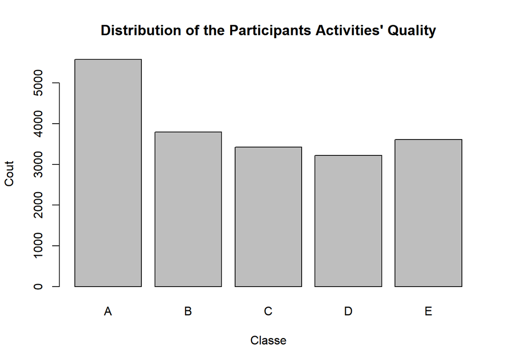

Distribution of the Participants Activities’ Quality

```r
#str(trndta)

#summary(trndta)

plot(trndta$classe,xlab = "Classe", ylab = "Cout" ,main = "Distribution of the Participants Activities' Quality")
```

## Data Cleaning and Feature Selection

In this part, some features are entierly deleted. By checking the frequency of the Na values, it seems that some features have more than 50% of the observations as NAs.

```r
L<-sapply(trndta, function(x) sum(is.na(x)))

vec<-which(L>=9608)

clnTrnDta<-trndta[,-vec]

clnTst<-tstdta[,-vec]
```

choose only a particular set of features; Remove features with almost Zero-variation, or not very important in the problem context.

```r
NZV<-nearZeroVar(clnTrnDta)

clnTrnDta<-clnTrnDta[,-NZV]

clnTst<-clnTst[,-NZV]

clnTrnDta<-clnTrnDta[,-c(1:5)]

clnTst<-clnTst[,-c(1:5)]
```

## Data Slicing

```r
InTrain<-createDataPartition(y=clnTrnDta$classe,p=0.75,list = FALSE)

training<-clnTrnDta[InTrain,]

testing<-clnTrnDta[-InTrain,]
```

## Data Exploration with Visualization

Since we have a large number of features, I tried to manually select some features (total accelartion) and explore their distribution with repect to the “classe” variable.

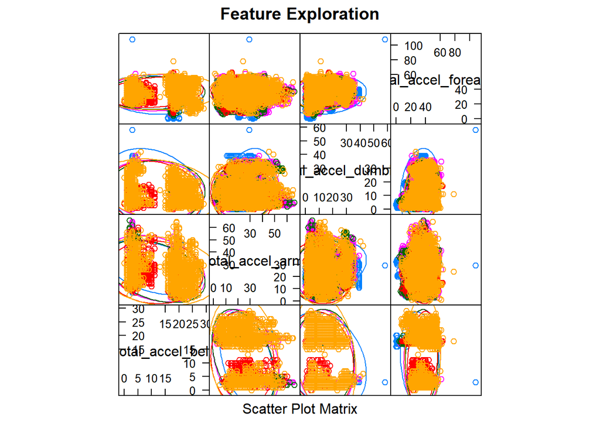

Feature Visualization

```r
Tot<- which(grepl("^total",names(training),ignore.case = F))

TotalAccel<-training[,Tot]

featurePlot(x=TotalAccel,y= training$classe,plot ="ellipse", main ="Feature Exploration" )
```

Understand the correlation between variables in order to check if we can exclude some redundant variables.

```r
CorrelationMatrix<-cor(TotalAccel)

print(CorrelationMatrix)
```

```
##                      total_accel_belt total_accel_arm total_accel_dumbbell
## total_accel_belt           1.00000000     -0.27061089           -0.1716091
## total_accel_arm           -0.27061089      1.00000000            0.1343684
## total_accel_dumbbell      -0.17160905      0.13436838            1.0000000
## total_accel_forearm        0.02386908     -0.07461632            0.1258550
##                      total_accel_forearm
## total_accel_belt              0.02386908
## total_accel_arm              -0.07461632
## total_accel_dumbbell          0.12585500
## total_accel_forearm           1.00000000
```

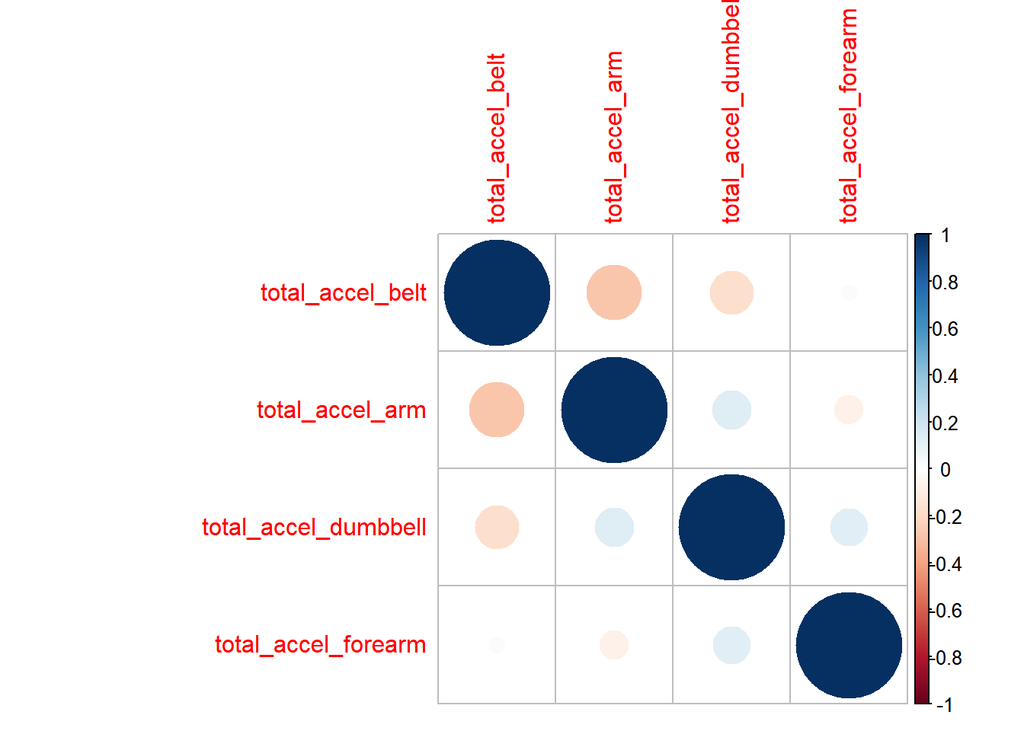

Features’ Correlation

```r
highlyCorrelated<-findCorrelation(CorrelationMatrix,cutoff = 0.5)

corrplot(CorrelationMatrix)
```

## Model Fitting

```r
set.seed(7)

trainControl <- trainControl(method="cv", number=5)

FitMdl<-train(classe~., data=training, method="rf", trainControl=trainControl)

Preds<-predict(FitMdl,testing[,-54])

confusionMatrix(Preds,testing$classe)
```

```
## Confusion Matrix and Statistics
##
##           Reference
## Prediction    A    B    C    D    E
##          A 1394    2    0    0    0
##          B    1  946    2    0    0
##          C    0    1  853    1    0
##          D    0    0    0  803    1
##          E    0    0    0    0  900
##
## Overall Statistics
##
##                Accuracy : 0.9984
##                  95% CI : (0.9968, 0.9993)
##     No Information Rate : 0.2845
##     P-Value [Acc > NIR] : < 2.2e-16
##
##                   Kappa : 0.9979
##  Mcnemar's Test P-Value : NA
##
## Statistics by Class:
##
##                      Class: A Class: B Class: C Class: D Class: E
## Sensitivity            0.9993   0.9968   0.9977   0.9988   0.9989
## Specificity            0.9994   0.9992   0.9995   0.9998   1.0000
## Pos Pred Value         0.9986   0.9968   0.9977   0.9988   1.0000
## Neg Pred Value         0.9997   0.9992   0.9995   0.9998   0.9998
## Prevalence             0.2845   0.1935   0.1743   0.1639   0.1837
## Detection Rate         0.2843   0.1929   0.1739   0.1637   0.1835
## Detection Prevalence   0.2847   0.1935   0.1743   0.1639   0.1835
## Balanced Accuracy      0.9994   0.9980   0.9986   0.9993   0.9994
```

```r
# estimate variable importance
importance <- varImp(FitMdl, scale=FALSE)

# summarize importance
print(importance)
```

```
## rf variable importance
##
##   only 20 most important variables shown (out of 53)
##
##                      Overall
## num_window            2220.2
## roll_belt             1325.0
## pitch_forearm          861.2
## yaw_belt               677.2
## magnet_dumbbell_z      639.2
## pitch_belt             601.3
## magnet_dumbbell_y      593.7
## roll_forearm           443.3
## accel_dumbbell_y       271.4
## magnet_dumbbell_x      247.8
## roll_dumbbell          247.3
## accel_forearm_x        222.0
## total_accel_dumbbell   204.0
## accel_belt_z           203.4
## magnet_belt_y          186.3
## accel_dumbbell_z       186.0
## magnet_belt_z          168.1
## magnet_forearm_z       150.1
## magnet_belt_x          141.8
## roll_arm               132.5
```

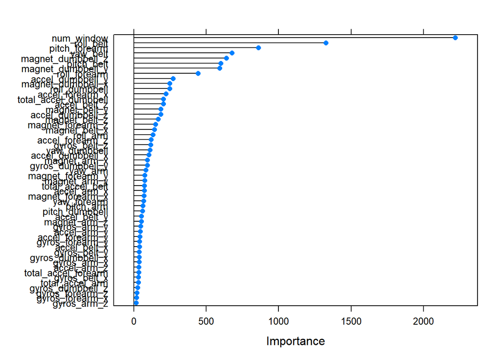

Importance of Features according to RF analysis

```r
# plot importance

plot(importance)
```

## Model Validation

In this section, I am comparing the In. and Out of Sample Error Values. As we know, in-sample error reflects the model accuracy on the training data which is usually small, or at lease much more slower than the out of sample error. We need a model that can be good enough to be generalized on new data so reduce overfitting

```r
 OutOfSmapleError<-sum(Preds!=testing$classe)/length(Preds)

OutOfSmapleError
```

[1] 0.001631321

```r
 PredsTrn<-predict(FitMdl,training[,-54])

  InSampleError<-sum(PredsTrn!=training$classe)/length(PredsTrn)

   InSampleError
```

[1] 0